# Canaries in the Data Mine Master FINAL

Alisa Hartle, Jared Kohler, Shreya Prabhu

Assigned: April 23, 2019

### Introduction

**This project’s aim has been to explore, analyze, and attempt to predict flight delays in minutes for flights coming to and from the Pittsburgh International Airport.**

### Data Processing

```r
library(knitr)
knitr::opts_chunk$set(cache = TRUE, warning = FALSE,
                      message = FALSE, cache.lazy = FALSE)
library(plyr)
library(knitr)
library(ggplot2)
library(dplyr)
library(glmnet)
library(readr)
library(tree)

#Government airport data is not downloadable annually, so it had to be downloaded as 12 national month files and then filtered and combined to only contain the Pittsburgh flights.

# datafiles <- lapply(Sys.glob("On_Time*.csv"), read_csv)
#
# month <- as.data.frame(datafiles[[1]])
# filter_month <- filter(month,month$Origin =="PIT"|month$Dest =="PIT")

# for (i in 2:12){
  # month1 <- as.data.frame(datafiles[[i]])
  # filter_month2 <- filter(month1,month1$Origin =="PIT"|month1$Dest =="PIT")
  # filter_month <<- rbind(filter_month, filter_month2)
# }

# write.csv(filter_month, file = "All_PIT_2018-19.csv ")
```

```r
#import Flight datasets
flight.df<<- as.data.frame(read_csv("All_PIT_2018-19.csv",col_names=TRUE))

flights.2006<-as.data.frame(read_csv("all_PIT_2006.csv",col_names=TRUE))

#import Master file from the Aircraft Registry
# MASTER <- data.frame(readr::read_csv("MASTER.txt"))

cbPalette <- c("#999999", "#E69F00", "#56B4E9", "#009E73", "#F0E442", "#0072B2", "#D55E00", "#CC79A7")
```

*Missing Values in Columns*

```r
#Omitting columns that are comprised of over 80% null values.
#(NAs? et al., 2019)
flight.df<-flight.df[, colSums(is.na(flight.df)) < .8*nrow(flight.df)]


#removing id row
flight.df<-flight.df[,-1]
x<-colSums(is.na(flight.df))
#print(x)

#This shows us that many of our columns now have no null values. All of these will eventually get filtered out for lasso later.

flight.df<- flight.df[, -which(names(flight.df) %in% c("DOT_ID_Reporting_Airline",
"IATA_CODE_Reporting_Airline",
"OriginAirportID",
"OriginAirportSeqID",
"OriginCityMarketID",
"OriginStateFips",
"OriginStateName",
"OriginWac",
"DestAirportID",
"DestAirportSeqID",
"DestCityMarketID",
"DestStateFips",
"DestStateName",
"DestWac"
))]
```

```r
#Here we are removing column(s) where all the values are the same.It's just one for the 2018-2019--a column "Flights" where the value is 1 for every row.

#(R and Fultz, 2019)
all.same<-vapply(flight.df, function(x) length(unique(x)) > 1, logical(1L))
flight.df<-subset(flight.df,select=-Flights)
```

```r
#Here we are calculating columns that do not exist from 2006 data.
not2006<-colnames(flight.df)[!(colnames(flight.df) %in% colnames(flights.2006))]
#print(length(not2006))
#print(not2006)
```

```r
#And now we're looking at columns that are in the 2006 data but not in the 2018 data
not2018<-colnames(flights.2006)[!(colnames(flights.2006) %in% colnames(flight.df))]
#print(length(not2018))
#print(not2018)
```

```r
#Now that we have an idea of which columns are "missing," it's clear some of these have just changed names. The code below matches inconsistent column names between 2006 and 2018-2019


#Deleting the AirlineID column in 2006 because it is redundant information.

flights.2006<-flights.2006[, -which(names(flights.2006) %in% c("AirlineID"))]


#flight.data$Flight_Number_Reporting_Airline %in% flights.2006$FlightNum

colnames(flights.2006)[colnames(flights.2006)=="FlightNum"]<-"Flight_Number_Reporting_Airline"

#flight.data$Tail_Number %in% flights.2006$TailNum

#commenting out as we've realized this is not a useful predictor, and really slows down processing time for lasso

#colnames(flights.2006)[colnames(flights.2006)=="TailNum"]<-"Tail_Number"


#flight.data$Reporting_Airline %in% flights.2006$UniqueCarrier

colnames(flights.2006)[colnames(flights.2006)=="UniqueCarrier"]<-"Reporting_Airline"
```

```r
#This code was created to merge the MASTER file into our flight.df2 dataset and converting the FlightDate column to a Date.

# MASTER$Tail_Number <- paste('N', MASTER$N.NUMBER, sep="")
# flight.df2 <- merge(x= flight.df, y = MASTER[, c("Tail_Number", "YEAR.MFR")], by = "Tail_Number", all.x=TRUE)
# sum(is.na(flight.df2$YEAR.MFR))

flight.df$FlightDate <- as.Date(flight.df$FlightDate , "%m/%d/%Y")
```

```r
#Creating variables for airline codes and airline names to facilitate data exploration

# airline_codes <- c(unique(flight.df2$Reporting_Airline))
# airline_names <- c("Allegiant", "Republic", "American","SkyWest", "ExpressJet", "United", "Pinnacle", "JetBlue", "SouthWest", "Frontier", "Comair", "American Eagle","Alaska", "Delta", "Mesa", "Spirit")
```

```r
#We've noticed that there are about 2,000 observations out of our 98,000+ flights where all of the Delay columns (ArrDelay, ArrDelayMinutes, etc.) are NA. Since we can't make any sort of prediction with these data, we are removing them from the dataset.

#(columns et al., 2019)

flight.df2 <- flight.df %>%
  filter_at(vars(ArrDelay), any_vars(!is.na(.)))

flight.df2 <- flight.df %>%
  filter_at(vars(DepDelay), any_vars(!is.na(.)))
```

```r
# flight.df2$ArrAirportDelayState <- ""
#
# time_blocks <- c(unique((flight.df2[order(flight.df2$ArrTimeBlk),])$ArrTimeBlk))
#
# flight.df2$ArrBlockCode <- match(flight.df2$ArrTimeBlk, time_blocks)
#
# for (row in 1:nrow(flight.df2))
#   {
#   date_of_row  <- flight.df2[row, "FlightDate"]
#   block_idx <- flight.df2[row, "ArrBlockCode"]
#   min_idx <- block_idx - 3
#   arr_airport <- flight.df2[row, "Dest"]
#
#   if(min_idx > 0){
#     date.df <- subset(flight.df2, FlightDate==date_of_row & Dest==arr_airport & between(flight.df2$ArrBlockCode, min_idx, block_idx-1))
#   }
#   else if(min_idx == -1 || min_idx == 0)
#   {
#     date.df <- subset(flight.df2, FlightDate==date_of_row & Dest==arr_airport & between(flight.df2$ArrBlockCode, 1, block_idx-1))
#   }
#   else
#   {
#     date.df <- subset(flight.df2, FlightDate==date_of_row-1 & Dest==arr_airport & between(flight.df2$ArrBlockCode, 17, 19))
#   }
#   flight.df2[row, "ArrAirportDelayState"] <- sum(date.df$ArrDel15)/nrow(date.df)
#   }
#
# flight.df2 <- transform(flight.df2, ArrAirportDelayState = as.numeric(ArrAirportDelayState))
```

```r
# flight.df2$OriginAirportDelayState <- ""
#
# flight.df2$DepBlockCode <- match(flight.df2$DepTimeBlk, time_blocks)
#
# for (row in 1:nrow(flight.df2))
#   {
#   date_of_row  <- flight.df2[row, "FlightDate"]
#   dep_idx <- flight.df2[row, "DepBlockCode"]
#   dep_min <- dep_idx - 3
#   origin_airport <- flight.df2[row, "Origin"]
#
#   if(dep_min > 0){
#     dep.df <- subset(flight.df2, FlightDate==date_of_row & Origin==origin_airport & between(flight.df2$DepBlockCode, dep_min, dep_idx-1))
#   }
#   else if(min_idx == -1 || min_idx == 0)
#   {
#     dep.df <- subset(flight.df2, FlightDate==date_of_row & Origin==origin_airport & between(flight.df2$DepBlockCode, 1, block_idx-1))
#   }
#   else
#   {
#     dep.df <- subset(flight.df2, FlightDate==date_of_row-1 & Origin==origin_airport & between(flight.df2$DepBlockCode, 17, 19))
#   }
#   flight.df2[row, "OriginAirportDelayState"] <- sum(dep.df$DepDel15)/nrow(dep.df)
#   }
#
# flight.df2 <- transform(flight.df2, OriginAirportDelayState = as.numeric(OriginAirportDelayState))
```

```r
#Time Block Variables 2: The Age of ArrTimeBlk

# flight.df2$ArrBlockCode <- match(flight.df2$ArrTimeBlk, time_blocks)
# flight.df2$PlaneDelayState <- ""
#
# for (row in 1:nrow(flight.df2))
#   {
#   date_of_row  <- flight.df2[row, "FlightDate"]
#   # print(date_of_row)
#   block_idx <- flight.df2[row, "ArrBlockCode"]
#   # print(block_idx)
#   Tail_Num <- flight.df2[row, "Tail_Number"]
#
#   if(block_idx > 1){
#     tail.df <- subset(flight.df2, FlightDate==date_of_row & Tail_Number==Tail_Num & ArrBlockCode>block_idx)
#   }
#   else
#   {
#     tail.df <- subset(flight.df2, FlightDate==date_of_row-1 & Tail_Number==Tail_Num & between(flight.df2$ArrBlockCode, 16, 19))
#   }
#   flight.df2[row, "PlaneDelayState"] <- sum(tail.df$ArrDel15)/nrow(tail.df)
#   }
#
# flight.df2 <- transform(flight.df2, PlaneDelayState = as.numeric(PlaneDelayState))
```

```r
# flight.df2$PlaneDelayAvg <- ""
#
# for (row in 1:nrow(flight.df2))
#   {
#   date_of_row  <- flight.df2[row, "FlightDate"]
#   block_idx <- flight.df2[row, "ArrBlockCode"]
#   Tail_Num <- flight.df2[row, "Tail_Number"]
#
#   if(block_idx > 1){
#     delay.df <- subset(flight.df2, FlightDate==date_of_row & Tail_Number==Tail_Num & ArrBlockCode>block_idx)
#     }
#   else
#   {
#     delay.df <- subset(flight.df2, FlightDate==date_of_row-1 & Tail_Number==Tail_Num & between(flight.df2$ArrBlockCode, 16, 19))
#   }
#   flight.df2[row, "PlaneDelayAvg"] <- sum(delay.df$ArrDelayMinutes)/nrow(delay.df)
#   }
#
# flight.df2 <- transform(flight.df2, PlaneDelayAvg = as.numeric(PlaneDelayAvg))
```

```r
# flight.df2$PlaneDelayAvg[is.na(flight.df2$PlaneDelayAvg)] <- 0
# flight.df2$PlaneDelayState[is.na(flight.df2$PlaneDelayState)] <- 0
# flight.df2$ArrAirportDelayState[is.na(flight.df2$ArrAirportDelayState)] <- 0
# flight.df2$OriginAirportDelayState[is.na(flight.df2$OriginAirportDelayState)] <- 0
```

```r
#write.csv(flight.df2, file = "flight.df3.csv")
flight.df3<-as.data.frame(read_csv("flight.df3.csv", col_names=TRUE))
flight.df3$X1 <- NULL
```

```r
#And now we delete repetative delay variables in anticipation of lasso.

flight.df3<- flight.df3[, -which(names(flight.df3) %in% c("DepTime","DepDelay","DepDelayMinutes","DepartureDelayGroups","ArrDelay","ArrDel15","ArrivalDelayGroups","DepDel15"))]
```

**In the initial pass at lasso, we realized that PA/Pittsburgh based variables were popping up as statistically significant. This certainly seems like a byproduct of only having flights that either originate or end up in Pittsburgh. Here we are creating groups differentiating between arrivals and departures for further data exploration and model testing.**

```r
flight.df3<- flight.df3 %>%
filter_at(vars(ArrDelayMinutes), any_vars(!is.na(.)))

pit.dep<-subset(flight.df3,flight.df3$OriginCityName=="Pittsburgh, PA")
pit.arr<-subset(flight.df3,flight.df3$DestCityName=="Pittsburgh, PA")


#The code below removes DestState, DestCityName, and Dest from Pittsburgh arrivals because these falls are all the same (PA or Pittsburgh)

#This code determines which columns only have one value throughout. The following line delets those columns by name.
#vapply(pit.arr, function(x) length(unique(x)) > 1, logical(1L))

pit.arr<-pit.arr[,-which (names(pit.arr) %in% c("DestState","DestCityName","Dest"))]

# #Doing the same with OriginState, OriginCityName, and Origin for Pittsburgh departures

#Again, deleting columns that just have one value
#vapply(pit.dep, function(x) length(unique(x)) > 1, logical(1L))
pit.dep<-pit.dep[,-which (names(pit.dep) %in% c("OriginState","OriginCityName","Origin"))]
```

### Exploratory Data Analysis

**Now we’re going to do some exploratory analysis on the variables of interest: ArrTime, WheelsOn,CRSArrTime, and TaxiOut

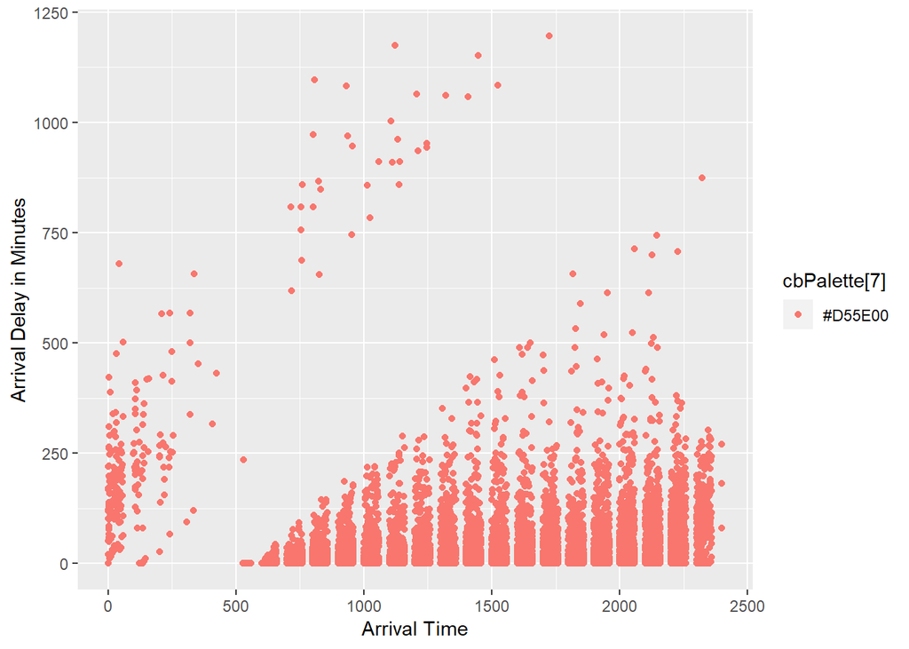

```r
qplot(x=ArrTime,y=ArrDelayMinutes, data=pit.dep,xlab="Arrival Time",ylab="Arrival Delay in Minutes",col=cbPalette[7])
```

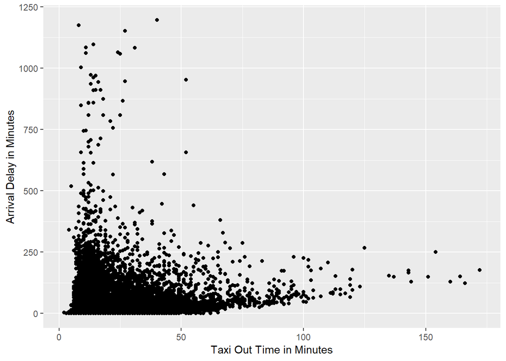

```r
qplot(x=TaxiOut,y=ArrDelayMinutes, data=pit.dep,xlab="Taxi Out Time in Minutes",ylab="Arrival Delay in Minutes")
```

**This plot provides some interesting insight about taxi out time. Its worth noting the plot above suggests any flight with a TaxiOut Time>80 will be delayed, which isn’t too shocking. For the most part, though, the data almost look as though they exhibit a negative relationship between Taxi Out Time and Arrival Delay in Minutes. However, its more likely that extreme delays of more than 300 minutes are quite rare, and these observations are more likely to be seen where data are highly concentrated on the x-axis.**

```r
summary(pit.dep$TaxiOut)
```

```
##    Min. 1st Qu.  Median    Mean 3rd Qu.    Max.
##    2.00   10.00   13.00   16.06   18.00  172.00
```

### Methodology

**We decided to look at predictive methods for determing flight arrival delays in minutes. The methods we thought would be most appropriate for this task were lasso for variable selection, regression trees, and linear models.**

### Lasso

**Here we fit lasso to the Pittsburgh Departures Dataset**

```r
#Here we are removing Tail_Number due to a considerable processing delay and previous lassos which suggested Tail_Number was not a useful predictor.

pit.dep<-pit.dep[,-which (names(pit.dep) %in% c("Tail_Number"))]

set.seed(1)
dep.x<-model.matrix(ArrDelayMinutes~.,pit.dep)[,-1]
dep.y<-pit.dep$ArrDelayMinutes
dep.lasso<-glmnet(x=dep.x,dep.y,family="gaussian",
                     alpha=1)
```

**Let’s take a look at how many lambdas lasso produced for Departures.**

```r
#dep.lasso$lambda
```

**Here we’re going to plot the relationship between coefficients and the various values of lambda**

```r
length(dep.lasso$lambda)
```

```
## [1] 90
```

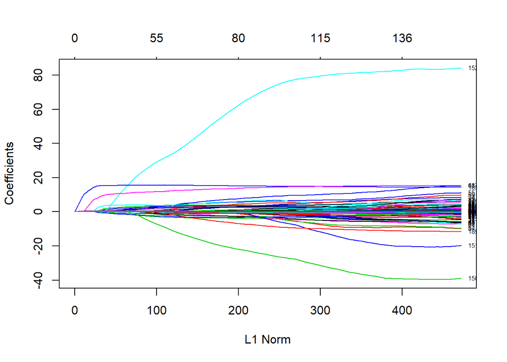

```r
plot(dep.lasso,xvar="norm",label=TRUE)
```

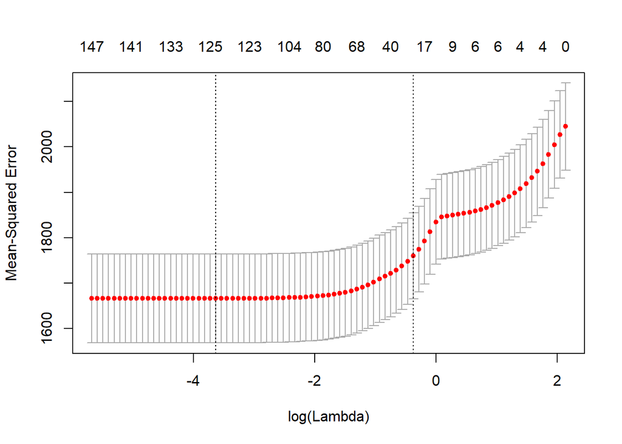

```r
dep.lasso.cv<-cv.glmnet(dep.x,dep.y,k=10)
plot(dep.lasso.cv)
```

**The graph above shows that a smaller MSE is associated with more negative values of lambda.**

**Now that we have cross-validated lasso, we’re going to look at the value for minimum CV error.**

```r
#This is checking what value of lambda minimizes CV error.

mincv <- which(dep.lasso.cv$lambda == dep.lasso.cv$lambda.min)

mincv.error<-dep.lasso.cv$cvm[mincv]
#(package?, 2019)
print(mincv.error)
```

```
## [1] 1666.424
```

**The minimum CV error for lasso is 1666.424. But a less complicated model may exist for similar error rates, so lets look at 1-SE**

```r
#Our value of lambda
uno.se<-dep.lasso.cv$lambda.1se
print(uno.se)
```

```
## [1] 0.6869798
```

```r
#The index of lambda so we can print the error
dep.1se<-which(dep.lasso.cv$lambda == dep.lasso.cv$lambda.1se)

#Code to print a more compact version of non-zero variables
grid=10^seq(10,-2,length=100)
fun<-glmnet(dep.x,dep.y,alpha=1,lambda=grid)
se.coef<-predict(fun, type="coefficients",s = uno.se)[1:191,]
se.coef[se.coef!=0]
```

```
##                    (Intercept)            Reporting_AirlineB6
##                  -1.558764e+01                   2.250262e+00
##            Reporting_AirlineDL            Reporting_AirlineOO
##                  -7.947779e-01                   4.576843e-01
##            Reporting_AirlineUA            Reporting_AirlineYX
##                   1.031891e+00                  -6.838366e-01
##                        DestIAD                        DestPHX
##                   4.310656e-01                  -2.750477e-01
##                        DestPIE                        DestSFO
##                   5.421088e-01                   3.756155e+00
##        DestCityNameChicago, IL       DestCityNameNew York, NY
##                  -8.162781e-01                   1.377611e-02
##        DestCityNamePhoenix, AZ  DestCityNameSan Francisco, CA
##                  -9.077163e-02                   1.276790e-11
## DestCityNameSt. Petersburg, FL                    DestStateFL
##                   1.574774e-05                   1.559104e+00
##                    DestStateIL                     CRSDepTime
##                  -1.162765e-02                  -3.417117e-02
##            DepTimeBlk2300-2359                        TaxiOut
##                   6.713134e+00                   5.987531e-01
##                      WheelsOff                         TaxiIn
##                   6.126575e-02                   3.040609e-01
##                     CRSArrTime                        ArrTime
##                  -2.563607e-03                  -1.496655e-02
##              ActualElapsedTime           ArrAirportDelayState
##                   1.618369e-02                   1.542191e+01
##                   ArrBlockCode        OriginAirportDelayState
##                  -1.599624e-04                   1.024724e+01
##                  PlaneDelayAvg
##                   3.528963e-01
```

```r
secv.error<-dep.lasso.cv$cvm[dep.1se]
print(secv.error)
```

```
## [1] 1760.095
```

**The 1-SE CV error for the Pittsburgh Departures model is 1760.095.**

**Now we’ll fit lasso to the Pittsburgh Arrivals Dataset**

```r
pit.arr<-pit.arr[,-which (names(pit.arr) %in% c("Tail_Number"))]

set.seed(1)
arr.x<-model.matrix(ArrDelayMinutes~.,pit.arr)[,-1]
arr.y<-pit.arr$ArrDelayMinutes
arr.lasso<-glmnet(x=arr.x,arr.y,family="gaussian",
                     alpha=1)
```

**Let’s take a look at how many lambdas lasso produced.**

```r
#arr.lasso$lambda
length(arr.lasso$lambda)
```

```
## [1] 99
```

**We have model fits for 99 values of lambda.**

**Here we’re going to plot the relationship between coefficients and the various values of lambda**

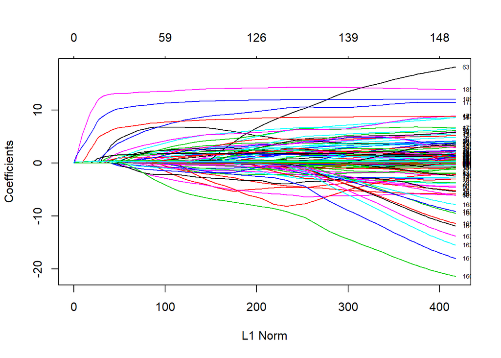

```r
plot(arr.lasso,xvar="norm",label=TRUE)
```

**These values for lambda are helpful, but let’s cross-validate all these models to see what selection of variables produces the lowest error.**

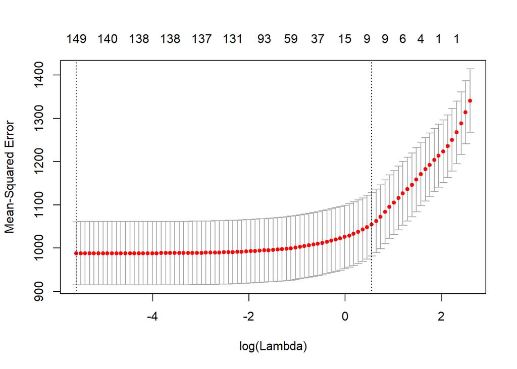

```r
arr.lasso.cv<-cv.glmnet(arr.x,arr.y,k=10)
plot(arr.lasso.cv)
```

**The graph above shows MSE for arrivals is lowest when log(Lamda) is more negative.**

**We’re going to select the value of lambda that produces a less complicated model within 1 standard error of the lambda that minimizes cv.**

```r
#our lambda value

uno.arr.se<-arr.lasso.cv$lambda.1se
print(uno.arr.se)
```

```
## [1] 1.734284
```

```r
arr.1se<-which(arr.lasso.cv$lambda == arr.lasso.cv$lambda.1se)

#the coefficients selected by lasso to be non-zero
fun2<-glmnet(arr.x,arr.y,alpha=1,lambda=grid)

se.arr.coef<-predict(fun2, type="coefficients",s = uno.arr.se)[1:191,]
#se.arr.coef
se.arr.coef[se.arr.coef!=0]
```

```
##             (Intercept)              CRSDepTime                 TaxiOut
##            -4.426133872             0.006829149             0.357141240
##                WheelsOn                 ArrTime     ArrTimeBlk2000-2059
##            -0.004384959            -0.004314517             0.026004392
##    ArrAirportDelayState            ArrBlockCode OriginAirportDelayState
##            11.416936789             0.675588563             4.280306422
##         PlaneDelayState           PlaneDelayAvg
##             7.493645570             0.262829426
```

```r
#error for this model
arr.secv.error<-arr.lasso.cv$cvm[arr.1se]
print(arr.secv.error)
```

```
## [1] 1054.845
```

```r
uno.arr.se<-arr.lasso.cv$lambda.1se
print(uno.arr.se)
```

```
## [1] 1.734284
```

**Overall, it seems that Pittsburgh arrivals are tougher to predict with the data available. While we have created a model with a lower 1-SE CV error of 1054.845, looking at the variables included it seems unlikely this has much predictive use. If anything, its likely this “predictors” are not predicting delays so much as producing the after-effects of delays which won’t be known until after a flight leaves.**

### Regression Trees

**Now for something completely different. We’re going to fit a regression tree model to the pit.dep dataset.**

```r
set.seed(1)
train<-sample(1:nrow(pit.dep),nrow(pit.dep)/2)
tree.flights<-tree(ArrDelayMinutes~.,pit.dep,subset=train)
summary(tree.flights)
```

```
##
## Regression tree:
## tree(formula = ArrDelayMinutes ~ ., data = pit.dep, subset = train)
## Variables actually used in tree construction:
## [1] "WheelsOff"            "ArrAirportDelayState" "TaxiOut"
## [4] "CRSDepTime"
## Number of terminal nodes:  6
## Residual mean deviance:  1756 = 42370000 / 24120
## Distribution of residuals:
##     Min.  1st Qu.   Median     Mean  3rd Qu.     Max.
## -257.400   -8.861   -8.861    0.000   -4.861 1165.000
```

**Interestingly enough, the regression tree seems to be taking a very different approach from lasso for the Pittsburgh departures dataset. To explore a little further, here’s a breakdown of the rules created by the regression tree.**

```r
tree(formula=ArrDelayMinutes~.,data=pit.dep,subset=train)
```

```
## node), split, n, deviance, yval
##       * denotes terminal node
##
##  1) root 24129 51670000  13.350
##    2) WheelsOff < 2121.5 23815 43610000  11.730
##      4) WheelsOff < 414.5 20   249500 283.400 *
##      5) WheelsOff > 414.5 23795 41880000  11.500
##       10) ArrAirportDelayState < 0.583333 22195 32770000   9.801
##         20) TaxiOut < 37.5 21410 29520000   8.861 *
##         21) TaxiOut > 37.5 785  2706000  35.450 *
##       11) ArrAirportDelayState > 0.583333 1600  8166000  35.020 *
##    3) WheelsOff > 2121.5 314  3227000 136.600
##      6) CRSDepTime < 1802.5 37   641500 326.000 *
##      7) CRSDepTime > 1802.5 277  1080000 111.300 *
```

**Here we have a plot of our regression tree.**

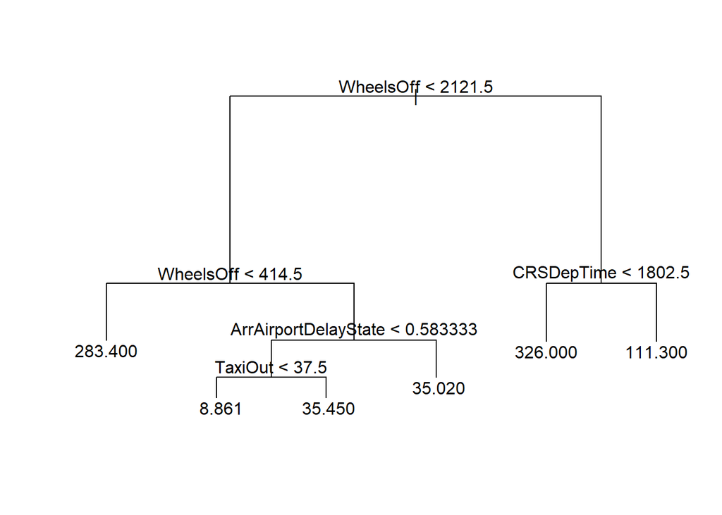

```r
plot(tree.flights)
text(tree.flights,pretty=0)
```

**This doesn’t seem particularly useful in predicting flights. WheelsOff Time is close to or the same as most values in CRSDepTime in the dataset. So essentially the only variables being included are departure time, taxi out time, and the created variable ArrAirportDelayState, or the likelihood of recent delays at the arrival airport.**

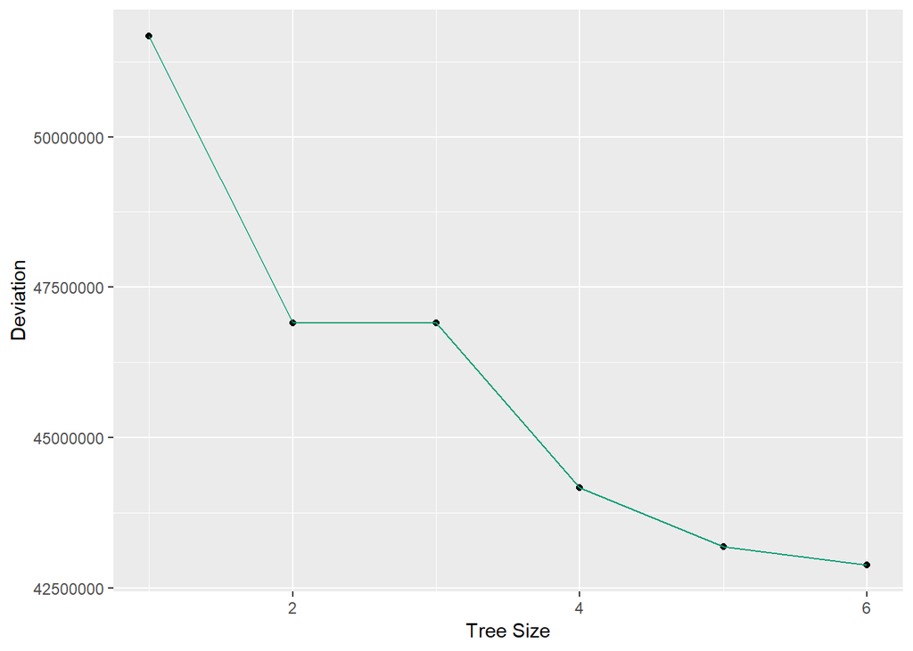

```r
#And now let's cross-validate our regression tree.

cv.flights<-cv.tree(tree.flights)
qplot(x=cv.flights$size,y=cv.flights$dev,xlab="Tree Size",ylab="Deviation")+geom_line(linetype=1,color=cbPalette[4])
```

**We pruned a tree and plotted it. This has been commented out in the final markdown because it wouldn’t knit and it wasn’t particularly useful (the largest tree had the lowest deviance)**

```r
#prune.flight<-prune.tree(tree.flights,newdata=pit.dep[-train,])
#pruned<-as.data.frame(cbind(prune.flight$size,prune.flight$dev))

#qplot(data=pruned,x=pruned[,1],y=pruned[,2],xlab="Tree Size",ylab="Deviance")+geom_line(linetype=1,color=cbPalette[3])
#text(x=pruned[,1],y=pruned[,2],pretty=0)
```

**This is code for the plot below. If our model was a perfect predictor, we would see all points along the abline. As we can see, many of the predicted delays are far less than the actual delay experienced.**

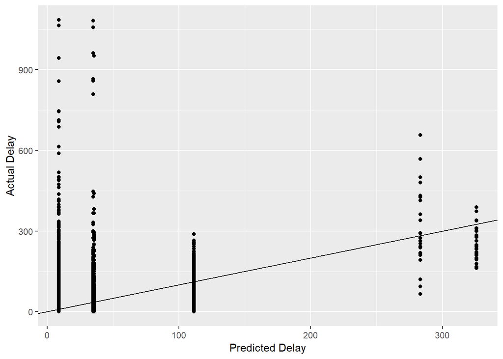

```r
yhat<-predict(tree.flights,newdata=pit.dep[-train,])
flight.test<-pit.dep[-train,"ArrDelayMinutes"]
qplot(x=yhat,y=flight.test,xlab="Predicted Delay",ylab="Actual Delay")+geom_abline(x=0,y=1)
```

```r
tree.mse<-mean((yhat-flight.test)^2)
sqrt.mse<-sqrt(tree.mse)
print(sqrt.mse)
```

```
## [1] 40.50049
```

**On average, the test predictions for this tree model are within 40.5 minutes of the true delay for each flight departing from Pittsburgh.**

### Key Findings and Questions Answered

**Our results were somewhat uninsightful when we looked at all flights coming to and from Pittsburgh, largely because variable selection models such as lasso conflated flights leaving Pittsburgh as being likely to cause delays due to overrepresentation in the dataset.**

**What features are useful in predicting flight delays?** **Things become a little more interesting when we divided the data by arrivals and departures. While the arrival flights variables determined by lasso didn’t seem particularly useful, lasso did pick up on some potentially insightful predictors for delyas like certain airlines and destinations.**

### Citations

*NAs?, H., Rigamonti, L., Cannell, B., O’Hanlon, S. and Jiang, S. (2019). How to delete columns that contain ONLY NAs?. [online] Stack Overflow. Available at: https://stackoverflow.com/questions/15968494/how-to-delete-columns-that-contain-only-nas/15968937 [Accessed 8 May 2019].*

*R, H. and Fultz, N. (2019). How to remove columns with same value in R. [online] Stack Overflow. Available at: https://stackoverflow.com/questions/30544282/how-to-remove-columns-with-same-value-in-r [Accessed 8 May 2019].*

*columns, R., Doe, J., C, L. and Fernandes, T. (2019). R - Remove rows which have all NAs in certain columns. [online] Stack Overflow. Available at: https://stackoverflow.com/questions/51596658/r-remove-rows-which-have-all-nas-in-certain-columns [Accessed 8 May 2019].*

*package?, H. (2019). How to extract the CV errors for optimal lambda using glmnet package?. [online] Stack Overflow. Available at: https://stackoverflow.com/questions/24018585/how-to-extract-the-cv-errors-for-optimal-lambda-using-glmnet-package [Accessed 8 May 2019].*